# Predict Bike Sharing Demand with AutoGluon Template

### Install packages

```python
!pip install -U pip
!pip install -U setuptools wheel
!pip install -U "mxnet<2.0.0" bokeh==2.0.1
!pip install autogluon --no-cache-dir
# Without --no-cache-dir, smaller aws instances may have trouble installing
```

[output not shown]

[output not shown]

[output cut: 42 more lines]

[output not shown]

### Setup Kaggle API Key

```python
# create the .kaggle directory and an empty kaggle.json file
!mkdir -p /root/.kaggle
!touch /root/.kaggle/kaggle.json
!chmod 600 /root/.kaggle/kaggle.json
```

```python
# Fill in your user name and key from creating the kaggle account and API token file
import json
kaggle_username = "toumimohamed"
kaggle_key = "**************************************"

# Save API token the kaggle.json file
with open("/root/.kaggle/kaggle.json", "w") as f:
    f.write(json.dumps({"username": kaggle_username, "key": kaggle_key}))
```

### Download and explore dataset

```python
# Download the dataset, it will be in a .zip file so you'll need to unzip it as well.
!kaggle competitions download -c bike-sharing-demand
# If you already downloaded it you can use the -o command to overwrite the file
!unzip -o bike-sharing-demand.zip
```

```
Downloading bike-sharing-demand.zip to /content
  0% 0.00/189k [00:00<?, ?B/s]
100% 189k/189k [00:00<00:00, 88.0MB/s]
Archive:  bike-sharing-demand.zip
  inflating: sampleSubmission.csv
  inflating: test.csv
  inflating: train.csv
```

```python
import pandas as pd
from autogluon.tabular import TabularPredictor
```

```python
# Create the train dataset in pandas by reading the csv
# Set the parsing of the datetime column so you can use some of the `dt` features in pandas later
train = pd.read_csv("train.csv")
train.head()
```

|  | datetime | season | holiday | workingday | weather | temp | atemp | humidity | windspeed | casual | registered | count |
| --- | --- | --- | --- | --- | --- | --- | --- | --- | --- | --- | --- | --- |
| 0 | 2011-01-01 00:00:00 | 1 | 0 | 0 | 1 | 9.84 | 14.395 | 81 | 0.0 | 3 | 13 | 16 |
| 1 | 2011-01-01 01:00:00 | 1 | 0 | 0 | 1 | 9.02 | 13.635 | 80 | 0.0 | 8 | 32 | 40 |
| 2 | 2011-01-01 02:00:00 | 1 | 0 | 0 | 1 | 9.02 | 13.635 | 80 | 0.0 | 5 | 27 | 32 |
| 3 | 2011-01-01 03:00:00 | 1 | 0 | 0 | 1 | 9.84 | 14.395 | 75 | 0.0 | 3 | 10 | 13 |
| 4 | 2011-01-01 04:00:00 | 1 | 0 | 0 | 1 | 9.84 | 14.395 | 75 | 0.0 | 0 | 1 | 1 |

```python
# Simple output of the train dataset to view some of the min/max/varition of the dataset features.
```

[output not shown]

```python
# Create the test pandas dataframe in pandas by reading the csv, remember to parse the datetime!
test = pd.read_csv("test.csv")
test.head()
```

|  | datetime | season | holiday | workingday | weather | temp | atemp | humidity | windspeed |
| --- | --- | --- | --- | --- | --- | --- | --- | --- | --- |
| 0 | 2011-01-20 00:00:00 | 1 | 0 | 1 | 1 | 10.66 | 11.365 | 56 | 26.0027 |
| 1 | 2011-01-20 01:00:00 | 1 | 0 | 1 | 1 | 10.66 | 13.635 | 56 | 0.0000 |
| 2 | 2011-01-20 02:00:00 | 1 | 0 | 1 | 1 | 10.66 | 13.635 | 56 | 0.0000 |
| 3 | 2011-01-20 03:00:00 | 1 | 0 | 1 | 1 | 10.66 | 12.880 | 56 | 11.0014 |
| 4 | 2011-01-20 04:00:00 | 1 | 0 | 1 | 1 | 10.66 | 12.880 | 56 | 11.0014 |

```python
# Same thing as train and test dataset
submission = pd.read_csv("sampleSubmission.csv",  parse_dates=["datetime"])
submission.head()
```

|  | datetime | count |
| --- | --- | --- |
| 0 | 2011-01-20 00:00:00 | 0 |
| 1 | 2011-01-20 01:00:00 | 0 |
| 2 | 2011-01-20 02:00:00 | 0 |
| 3 | 2011-01-20 03:00:00 | 0 |
| 4 | 2011-01-20 04:00:00 | 0 |

## Step 3: Train a model using AutoGluon’s Tabular Prediction

Requirements:

- We are prediting `count`, so it is the label we are setting.
- Ignore `casual` and `registered` columns as they are also not present in the test dataset.
- Use the `root_mean_squared_error` as the metric to use for evaluation.
- Set a time limit of 10 minutes (600 seconds).
- Use the preset `best_quality` to focus on creating the best model.

```python
predictor = TabularPredictor(
    label='count',
    eval_metric='root_mean_squared_error',
    learner_kwargs={'ignored_columns': ['casual', 'registered']}
    ).fit(
    train_data=train,
    time_limit=600,
    presets='best_quality'
    )
```

[output not shown]

[output cut: 71 more lines]

[output not shown]

### Review AutoGluon's training run with ranking of models that did the best.

```python
predictor.fit_summary()
```

```
*** Summary of fit() ***
Estimated performance of each model:
                     model   score_val  pred_time_val    fit_time  pred_time_val_marginal  fit_time_marginal  stack_level  can_infer  fit_order
0      WeightedEnsemble_L3  -52.812486      13.054085  492.123765                0.000980           0.529036            3       True         15
1   RandomForestMSE_BAG_L2  -53.419761      11.670720  391.480411                0.481694          26.516621            2       True         12
2     ExtraTreesMSE_BAG_L2  -53.830873      11.829117  375.266159                0.640091          10.302369            2       True         14
3          LightGBM_BAG_L2  -55.037516      11.860921  389.746617                0.671896          24.782827            2       True         11
4          CatBoost_BAG_L2  -55.501949      11.259424  429.992913                0.070399          65.029123            2       True         13
5        LightGBMXT_BAG_L2  -60.299195      14.822678  415.601631                3.633652          50.637841            2       True         10
6    KNeighborsDist_BAG_L1  -84.125061       0.065978    0.073783                0.065978           0.073783            1       True          2
7      WeightedEnsemble_L2  -84.125061       0.066739    0.568937                0.000762           0.495153            2       True          9
8    KNeighborsUnif_BAG_L1 -101.546199       0.099382    0.103138                0.099382           0.103138            1       True          1
9   RandomForestMSE_BAG_L1 -116.548359       0.536969    8.311455                0.536969           8.311455            1       True          5
10    ExtraTreesMSE_BAG_L1 -124.600676       0.409967    3.754605                0.409967           3.754605            1       True          7
11         CatBoost_BAG_L1 -130.493775       0.138343  195.212129                0.138343         195.212129            1       True          6
12         LightGBM_BAG_L1 -131.054162       1.084628   27.466953                1.084628          27.466953            1       True          4
13       LightGBMXT_BAG_L1 -131.460909       8.340710   57.475237                8.340710          57.475237            1       True          3
14  NeuralNetFastAI_BAG_L1 -138.768838       0.513049   72.566489                0.513049          72.566489            1       True          8
Number of models trained: 15
Types of models trained:
{'StackerEnsembleModel_KNN', 'WeightedEnsembleModel', 'StackerEnsembleModel_NNFastAiTabular', 'StackerEnsembleModel_LGB', 'StackerEnsembleModel_RF', 'StackerEnsembleModel_CatBoost', 'StackerEnsembleModel_XT'}
Bagging used: True  (with 8 folds)
Multi-layer stack-ensembling used: True  (with 3 levels)
Feature Metadata (Processed):
(raw dtype, special dtypes):
('float', [])                : 3 | ['temp', 'atemp', 'windspeed']
('int', [])                  : 3 | ['season', 'weather', 'humidity']
('int', ['bool'])            : 2 | ['holiday', 'workingday']
('int', ['datetime_as_int']) : 5 | ['datetime', 'datetime.year', 'datetime.month', 'datetime.day', 'datetime.dayofweek']
```

[output not shown]

```
*** End of fit() summary ***
```

[output not shown]

[output cut: 139 more lines]

[output not shown]

### Create predictions from test dataset

```python
predictions = predictor.predict(test)
predictions.head()
```

```
0    24.766644
1    41.889122
2    45.875217
3    47.832123
4    50.660767
Name: count, dtype: float32
```

#### NOTE: Kaggle will reject the submission if we don't set everything to be > 0.

```python
# Describe the `predictions` series to see if there are any negative values
predictions.describe()
```

```
count    6493.000000
mean      100.837433
std        90.283066
min         3.061122
25%        20.426394
50%        63.392685
75%       169.761566
max       366.117218
Name: count, dtype: float64
```

```python
# How many negative values do we have?
predictions.lt(0).value_counts()
```

```
False    6493
Name: count, dtype: int64
```

```python
# Set them to zero
predictions.iloc[predictions<0] = 0
```

### Set predictions to submission dataframe, save, and submit

```python
submission['count'] = predictions
submission.to_csv("submission.csv", index=False)
```

```python
!kaggle competitions submit -c bike-sharing-demand -f submission.csv -m "first raw submission"
```

```
100% 188k/188k [00:01<00:00, 171kB/s]
Successfully submitted to Bike Sharing Demand
```

#### View submission via the command line or in the web browser under the competition's page - `My Submissions`

```python
!kaggle competitions submissions -c bike-sharing-demand | tail -n +1 | head -n 6
```

```
fileName        date                 description           status    publicScore  privateScore
--------------  -------------------  --------------------  --------  -----------  ------------
submission.csv  2023-05-27 02:30:50  first raw submission  complete  1.80659      1.80659
submission.csv  2023-05-26 18:01:01  first raw submission  complete  1.80470      1.80470
```

## Step 4: Exploratory Data Analysis and Creating an additional feature

- Any additional feature will do, but a great suggestion would be to separate out the datetime into hour, day, or month parts.

```
array([[<Axes: title={'center': 'season'}>,
        <Axes: title={'center': 'holiday'}>,
        <Axes: title={'center': 'workingday'}>],
       [<Axes: title={'center': 'weather'}>,
        <Axes: title={'center': 'temp'}>,
        <Axes: title={'center': 'atemp'}>],
       [<Axes: title={'center': 'humidity'}>,
        <Axes: title={'center': 'windspeed'}>,
        <Axes: title={'center': 'casual'}>],
       [<Axes: title={'center': 'registered'}>,
        <Axes: title={'center': 'count'}>, <Axes: >]], dtype=object)
```

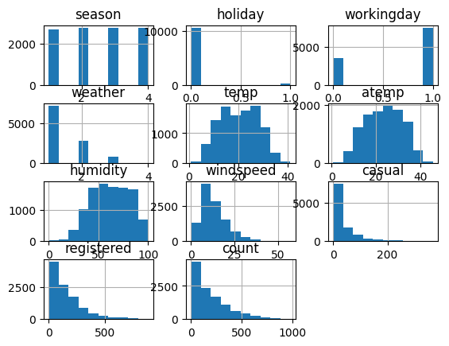

```python
# Create a histogram of all features to show the distribution of each one relative to the data. This is part of the exploritory data analysis
train.hist()
```

|  | season | holiday | workingday | weather | temp | atemp | humidity | windspeed | casual | registered | count | month | day | hour |
| --- | --- | --- | --- | --- | --- | --- | --- | --- | --- | --- | --- | --- | --- | --- |
| 0 | 1 | 0 | 0 | 1 | 9.84 | 14.395 | 81 | 0.0 | 3 | 13 | 16 | 1 | 1 | 0 |
| 1 | 1 | 0 | 0 | 1 | 9.02 | 13.635 | 80 | 0.0 | 8 | 32 | 40 | 1 | 1 | 1 |
| 2 | 1 | 0 | 0 | 1 | 9.02 | 13.635 | 80 | 0.0 | 5 | 27 | 32 | 1 | 1 | 2 |
| 3 | 1 | 0 | 0 | 1 | 9.84 | 14.395 | 75 | 0.0 | 3 | 10 | 13 | 1 | 1 | 3 |
| 4 | 1 | 0 | 0 | 1 | 9.84 | 14.395 | 75 | 0.0 | 0 | 1 | 1 | 1 | 1 | 4 |

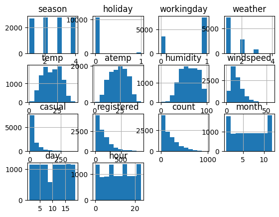

```python
# create a new feature
train['month'] = pd.to_datetime(train['datetime']).dt.month
train['day'] = pd.to_datetime(train['datetime']).dt.day
train['hour'] = pd.to_datetime(train['datetime']).dt.hour
test['month'] = pd.to_datetime(test['datetime']).dt.month
test['day'] = pd.to_datetime(test['datetime']).dt.day
test['hour'] = pd.to_datetime(test['datetime']).dt.hour

train = train.drop(columns=['datetime'])
test = test.drop(columns=['datetime'])
train.hist()
train.head()
```

## Make category types for these so models know they are not just numbers

- AutoGluon originally sees these as ints, but in reality they are int representations of a category.
- Setting the dtype to category will classify these as categories in AutoGluon.

```python
train["season"] = train["season"].astype("category")
train["weather"] = train["weather"].astype("category")
test["season"] = test["season"].astype("category")
test["weather"] = test["weather"].astype("category")
```

```python
# View are new feature
train.head()
```

|  | season | holiday | workingday | weather | temp | atemp | humidity | windspeed | casual | registered | count | month | day | hour |
| --- | --- | --- | --- | --- | --- | --- | --- | --- | --- | --- | --- | --- | --- | --- |
| 0 | 1 | 0 | 0 | 1 | 9.84 | 14.395 | 81 | 0.0 | 3 | 13 | 16 | 1 | 1 | 0 |
| 1 | 1 | 0 | 0 | 1 | 9.02 | 13.635 | 80 | 0.0 | 8 | 32 | 40 | 1 | 1 | 1 |
| 2 | 1 | 0 | 0 | 1 | 9.02 | 13.635 | 80 | 0.0 | 5 | 27 | 32 | 1 | 1 | 2 |
| 3 | 1 | 0 | 0 | 1 | 9.84 | 14.395 | 75 | 0.0 | 3 | 10 | 13 | 1 | 1 | 3 |
| 4 | 1 | 0 | 0 | 1 | 9.84 | 14.395 | 75 | 0.0 | 0 | 1 | 1 | 1 | 1 | 4 |

```
array([[<Axes: title={'center': 'holiday'}>,
        <Axes: title={'center': 'workingday'}>,
        <Axes: title={'center': 'temp'}>],
       [<Axes: title={'center': 'atemp'}>,
        <Axes: title={'center': 'humidity'}>,
        <Axes: title={'center': 'windspeed'}>],
       [<Axes: title={'center': 'casual'}>,
        <Axes: title={'center': 'registered'}>,
        <Axes: title={'center': 'count'}>],
       [<Axes: title={'center': 'month'}>,
        <Axes: title={'center': 'day'}>,
        <Axes: title={'center': 'hour'}>]], dtype=object)
```

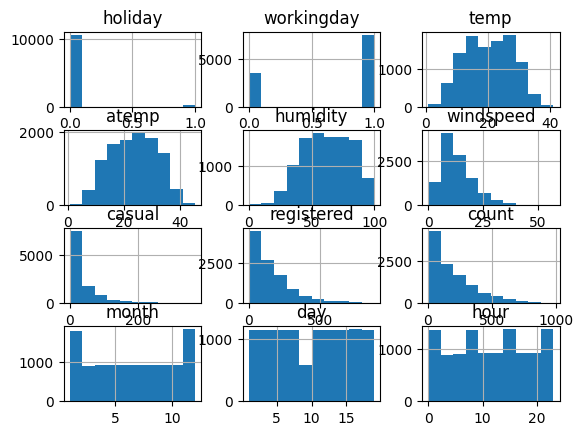

```python
# View histogram of all features again now with the hour feature
train.hist()
```

## Step 5: Rerun the model with the same settings as before, just with more features

```python
predictor_new_features = TabularPredictor(
    label='count',
    eval_metric='root_mean_squared_error',
    learner_kwargs={'ignored_columns': ['casual', 'registered']}
    ).fit(
    train_data=train,
    time_limit=600,
    presets='best_quality'
    )
```

[output not shown]

[output cut: 74 more lines]

[output not shown]

```python
predictor_new_features.fit_summary()
```

```
*** Summary of fit() ***
Estimated performance of each model:
                     model   score_val  pred_time_val    fit_time  pred_time_val_marginal  fit_time_marginal  stack_level  can_infer  fit_order
0      WeightedEnsemble_L3  -49.768955      58.888040  539.245980                0.000470           0.248702            3       True         16
1     ExtraTreesMSE_BAG_L2  -50.069928      57.846882  407.611280                0.484335           8.612660            2       True         14
2   RandomForestMSE_BAG_L2  -50.370594      57.875922  432.507702                0.513375          33.509082            2       True         12
3          CatBoost_BAG_L2  -50.447353      57.465937  451.459701                0.103390          52.461081            2       True         13
4          LightGBM_BAG_L2  -50.802604      57.467641  419.410285                0.105094          20.411664            2       True         11
5      WeightedEnsemble_L2  -51.371349      56.101407  356.779263                0.000542           0.292558            2       True          9
6   NeuralNetFastAI_BAG_L2  -51.651660      57.786469  444.414456                0.423922          45.415835            2       True         15
7        LightGBMXT_BAG_L2  -51.993047      58.616140  421.583862                1.253594          22.585242            2       True         10
8        LightGBMXT_BAG_L1  -52.689487      46.831505  116.709809               46.831505         116.709809            1       True          3
9          LightGBM_BAG_L1  -53.032788       8.534790   64.668413                8.534790          64.668413            1       True          4
10         CatBoost_BAG_L1  -57.045355       0.107315  158.704134                0.107315         158.704134            1       True          6
11    ExtraTreesMSE_BAG_L1  -64.134737       0.539580    3.612387                0.539580           3.612387            1       True          7
12  RandomForestMSE_BAG_L1  -64.174579       0.627256   16.404349                0.627256          16.404349            1       True          5
13   KNeighborsDist_BAG_L1 -119.365601       0.120999    0.020672                0.120999           0.020672            1       True          2
14  NeuralNetFastAI_BAG_L1 -119.777736       0.483825   38.850762                0.483825          38.850762            1       True          8
15   KNeighborsUnif_BAG_L1 -123.933260       0.117277    0.028095                0.117277           0.028095            1       True          1
Number of models trained: 16
Types of models trained:
{'StackerEnsembleModel_KNN', 'WeightedEnsembleModel', 'StackerEnsembleModel_NNFastAiTabular', 'StackerEnsembleModel_LGB', 'StackerEnsembleModel_RF', 'StackerEnsembleModel_CatBoost', 'StackerEnsembleModel_XT'}
Bagging used: True  (with 8 folds)
Multi-layer stack-ensembling used: True  (with 3 levels)
Feature Metadata (Processed):
(raw dtype, special dtypes):
('category', [])  : 2 | ['season', 'weather']
('float', [])     : 3 | ['temp', 'atemp', 'windspeed']
('int', [])       : 4 | ['humidity', 'month', 'day', 'hour']
('int', ['bool']) : 2 | ['holiday', 'workingday']
*** End of fit() summary ***
```

[output not shown]

[output cut: 151 more lines]

[output not shown]

```python
# Remember to set all negative values to zero
predictor_new_features = predictor_new_features.predict(test)
predictor_new_features.lt(0).value_counts()
predictor_new_features.iloc[predictor_new_features<0] = 0
```

```python
# Same submitting predictions
submission_new_features["count"] = predictor_new_features
submission_new_features.to_csv("submission_new_features.csv", index=False)
```

```python
!kaggle competitions submit -c bike-sharing-demand -f submission_new_features.csv -m "new features"
```

```
100% 188k/188k [00:01<00:00, 166kB/s]
Successfully submitted to Bike Sharing Demand
```

```python
!kaggle competitions submissions -c bike-sharing-demand | tail -n +1 | head -n 6
```

```
fileName                     date                 description           status    publicScore  privateScore
---------------------------  -------------------  --------------------  --------  -----------  ------------
submission_new_features.csv  2023-05-27 02:51:17  new features          complete  0.53929      0.53929
submission.csv               2023-05-27 02:30:50  first raw submission  complete  1.80659      1.80659
submission.csv               2023-05-26 18:01:01  first raw submission  complete  1.80470      1.80470
```

## Step 6: Hyper parameter optimization

- There are many options for hyper parameter optimization.
- Options are to change the AutoGluon higher level parameters or the individual model hyperparameters.
- The hyperparameters of the models themselves that are in AutoGluon. Those need the `hyperparameter` and `hyperparameter_tune_kwargs` arguments.

```python
hyperparameters = 'light'
hyperparameter_tune_kwargs = {
    'num_trials': 5,
    'searcher': 'random',
}

predictor_new_hpo = TabularPredictor(
    label='count',
    eval_metric='root_mean_squared_error',
    learner_kwargs={'ignored_columns': ['casual', 'registered']}
    ).fit(
    train_data=train,
    time_limit=1200,
    presets='best_quality',
    num_bag_folds=16,
    num_bag_sets=1,
    num_stack_levels=1,
    hyperparameters=hyperparameters,
    hyperparameter_tune_kwargs=hyperparameter_tune_kwargs,
    )
```

[output not shown]

[output cut: 219 more lines]

[output not shown]

```python
predictor_new_hpo.fit_summary()
```

```
*** Summary of fit() ***
Estimated performance of each model:
                  model  score_val  pred_time_val    fit_time  pred_time_val_marginal  fit_time_marginal  stack_level  can_infer  fit_order
0  LightGBMLarge_BAG_L1 -50.846405       7.341833  153.845585                7.341833         153.845585            1       True          1
1   WeightedEnsemble_L2 -50.846405       7.343339  153.855830                0.001506           0.010245            2       True          2
2  LightGBMLarge_BAG_L2 -54.997741       7.758675  215.759198                0.416842          61.913613            2       True          3
3   WeightedEnsemble_L3 -54.997741       7.759153  215.762681                0.000479           0.003482            3       True          4
Number of models trained: 4
Types of models trained:
{'WeightedEnsembleModel', 'StackerEnsembleModel_LGB'}
Bagging used: True  (with 16 folds)
Multi-layer stack-ensembling used: True  (with 3 levels)
Feature Metadata (Processed):
(raw dtype, special dtypes):
('category', [])  : 2 | ['season', 'weather']
('float', [])     : 3 | ['temp', 'atemp', 'windspeed']
('int', [])       : 4 | ['humidity', 'month', 'day', 'hour']
('int', ['bool']) : 2 | ['holiday', 'workingday']
*** End of fit() summary ***
```

[output not shown]

```python
# Remember to set all negative values to zero
predictor_new_hpo = predictor_new_hpo.predict(test)
predictor_new_hpo.lt(0).value_counts()

predictor_new_hpo.iloc[predictor_new_hpo<0] = 0
```

```python
# Same submitting predictions

submission_new_hpo["count"] = predictor_new_hpo
submission_new_hpo.to_csv("submission_new_hpo.csv", index=False)
```

```python
!kaggle competitions submit -c bike-sharing-demand -f submission_new_hpo.csv -m "new features with hyperparameters"
```

```
100% 187k/187k [00:01<00:00, 107kB/s]
Successfully submitted to Bike Sharing Demand
```

```python
!kaggle competitions submissions -c bike-sharing-demand | tail -n +1 | head -n 6
```

```
fileName                     date                 description                        status    publicScore  privateScore
---------------------------  -------------------  ---------------------------------  --------  -----------  ------------
submission_new_hpo.csv       2023-05-27 03:59:58  new features with hyperparameters  complete  0.64194      0.64194
submission_new_hpo.csv       2023-05-27 03:20:38  new features with hyperparameters  complete  0.63101      0.63101
submission_new_hpo.csv       2023-05-27 03:04:24  new features with hyperparameters  complete  0.63101      0.63101
submission_new_features.csv  2023-05-27 02:51:17  new features                       complete  0.53929      0.53929
```

## Step 7: Write a Report

### Refer to the markdown file for the full report

### Creating plots and table for report

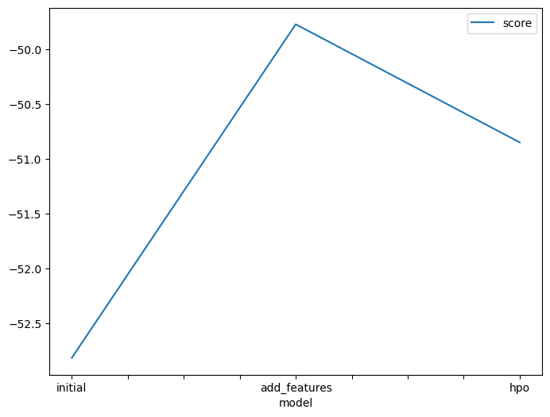

```python
# Taking the top model score from each training run and creating a line plot to show improvement
# You can create these in the notebook and save them to PNG or use some other tool (e.g. google sheets, excel)
fig = pd.DataFrame(
    {
        "model": ["initial", "add_features", "hpo"],
        "score": [-52.812486,
        -49.768955 ,
       -50.846405]
    }
).plot(x="model", y="score", figsize=(8, 6)).get_figure()
fig.savefig('model_train_score.png')
```

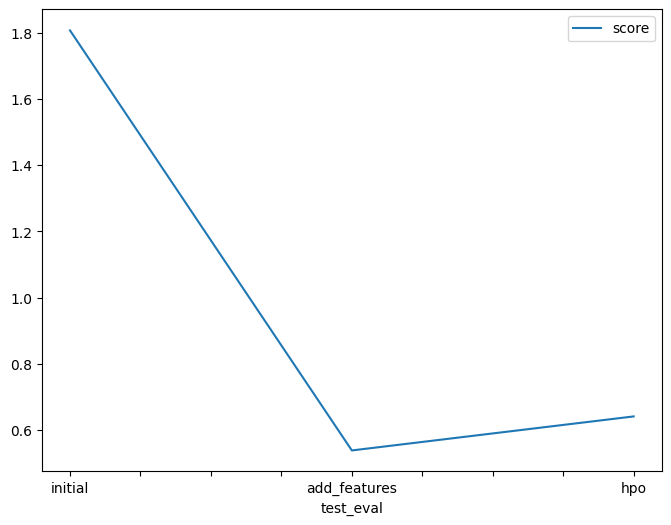

```python
# Take the 3 kaggle scores and creating a line plot to show improvement
fig = pd.DataFrame(
    {
        "test_eval": ["initial", "add_features", "hpo"],
        "score": [1.80659, 0.53929,  0.64194]
    }
).plot(x="test_eval", y="score", figsize=(8, 6)).get_figure()
fig.savefig('model_test_score.png')
```

### Hyperparameter table

```python
# The 3 hyperparameters we tuned with the kaggle score as the result
pd.DataFrame({
    "model": ["initial", "add_features", "hpo"],
    "time_limit": [600, 600, 1200],
    "num_bag_folds": [8, 8, 16],
    "num_trials": [1, 1, 5],
    "score": [1.80659, 0.53929, 0.64194]
})
```

|  | model | time_limit | num_bag_folds | num_trials | score |
| --- | --- | --- | --- | --- | --- |
| 0 | initial | 600 | 8 | 1 | 1.80659 |
| 1 | add_features | 600 | 8 | 1 | 0.53929 |
| 2 | hpo | 1200 | 16 | 5 | 0.64194 |